## MNIST classification using *LeNet300*

# Importing Keras

```python
# Importing the Keras 3.x main module relying on tensorflow 2.x backend
import tensorflow as tf
import keras
print("Using tensorflow version " + str(tf.__version__))
print("Using keras version " + str(keras.__version__))
```

```
Using tensorflow version 2.20.0
Using keras version 3.12.0
```

# Loading and preparing the MNIST dataset

Load the MNIST dataset made available by keras.datasets Verify the amount of system memory available before and after loading the dataset.

```python
# The MNSIT dataset is ready to be imported from Keras into RAM
from keras.datasets import mnist
# START CODE HERE
# tracemalloc.start()
# shot1 = tracemalloc.take_snapshot()

((x_train, y_train), (x_test, y_test)) = mnist.load_data()

# shot2 = tracemalloc.take_snapshot()
# top_stats = shot2.compare_to(shot1, 'lineno')
# print("[ Top 10 differences ]")
# for stat in top_stats[:10]:
#     print(stat)

# END CODE HERE
```

Using the pyplot package, visualize the fist sample of the training set

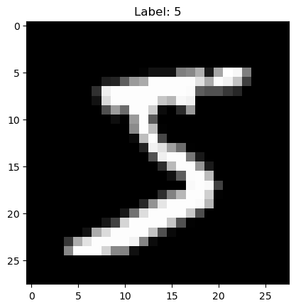

```python
# Let us visualize the first training sample using the Gnuplot library
from matplotlib import pyplot as plt
# START CODE HERE
x_train_0 = x_train[0, :, :]
plt.imshow(x_train_0, cmap='gray')
plt.title('Label: ' + str(y_train[0]))
plt.show()
# END CODE HERE
```

Turn train and test labels to one-hot encoding

```python
from keras.utils import to_categorical
# START CODE HERE
y_train_ohe = to_categorical(y_train, num_classes=10)
y_test_ohe = to_categorical(y_test, num_classes=10)
# END CODE HERE
```

Reshape train and test images so that they follow the NWHC ordering required by the TF backend. Then, after casting the pixels to floats, normalize the images so that they have zero-mean and unitary deviation

```python
# Reshape to proper images with 1 color channel according to backend scheme
img_rows, img_cols = x_train.shape[1], x_train.shape[2]
x_train = x_train.reshape(x_train.shape[0], img_rows, img_cols, 1)
# START CODE HERE
x_test = x_test.reshape(x_test.shape[0], img_rows, img_cols, 1)
# END CODE HERE

# Cast pixels from uint8 to float32
x_train = x_train.astype('float32')
x_test = x_test.astype('float32')

# Now let us normalize the images so that they have zero mean and standard deviation
# Hint: testing data statistics known at training time ?
# START CODE HERE
mean = x_train.mean()
std = x_train.std()
x_train = (x_train - mean) / std
x_test = (x_test - mean) / std

# **CORRECCIÓN: Ahora aplanar después de normalizar**
x_train_flat = x_train.reshape(x_train.shape[0], img_rows * img_cols)
x_test_flat = x_test.reshape(x_test.shape[0], img_rows * img_cols)
# END CODE HERE
```

# Defining the neural network architecture (i.e., the network model)

Create a LeNet300-like fully connected network taking in input the images as vectors of pixels and suitable to classify each image across 10 different classes. For this first implementation of the network, use only sigmoid activations in the hidden layer. Which activation function shall be used for the output layer ?

```python
# The Sequential module is a container for more complex NN elements and
# defines a loop-less NN architecture
from keras.models import Sequential
from keras.layers import Input, Dense

# START CODE HERE
model = Sequential()
model.add(Input(shape=(img_rows*img_cols,)))
model.add(Dense(300, activation='sigmoid'))
model.add(Dense(100, activation='sigmoid'))
model.add(Dense(10, activation='softmax'))
# END CODE HERE
```

Instantiate a SGD optimizer with a tentative LR of 10^-4 and using the appropriate loss function and compile the model.

```python
# The optimizers module provides a number of optimization algorithms for updating
# a netwok parameters accoridng to the computed error gradints
# START CODE HERE
optimizer=tf.keras.optimizers.SGD(learning_rate= 10e-4)

# Compiling a model in Keras amounts to associating th eoptimizer to a model with an appropriate loss function
model.compile(optimizer=optimizer,
              loss='categorical_crossentropy',
              metrics=['accuracy'])

# END CODE HERE
# We can now have a look at the defined model topology
model.summary()
```

```
Model: "sequential"
```

```
┏━━━━━━━━━━━━━━━━━━━━━━━━━━━━━━━━━┳━━━━━━━━━━━━━━━━━━━━━━━━┳━━━━━━━━━━━━━━━┓
┃ Layer (type)                    ┃ Output Shape           ┃       Param # ┃
┡━━━━━━━━━━━━━━━━━━━━━━━━━━━━━━━━━╇━━━━━━━━━━━━━━━━━━━━━━━━╇━━━━━━━━━━━━━━━┩
│ dense (Dense)                   │ (None, 300)            │       235,500 │
├─────────────────────────────────┼────────────────────────┼───────────────┤
│ dense_1 (Dense)                 │ (None, 100)            │        30,100 │
├─────────────────────────────────┼────────────────────────┼───────────────┤
│ dense_2 (Dense)                 │ (None, 10)             │         1,010 │
└─────────────────────────────────┴────────────────────────┴───────────────┘
```

```
 Total params: 266,610 (1.02 MB)
```

```
 Trainable params: 266,610 (1.02 MB)
```

```
 Non-trainable params: 0 (0.00 B)
```

# Training the network

Train the model for 10 epochs using the fit() method, without batch training initially validating the model at each epoch and keeping track of the training history for later plotting. Make sure you enable fit() verbose mode for interactive output.

```python
# This is where the actual training-validation happens

# START CODE HERE
# batch_size = ... Initialy with no Batch size
# Number of epochs we want to train
epochs = 10
# Lt s start the training
history=model.fit(x_train_flat, y_train_ohe,
                  epochs=epochs,
                  validation_data=(x_test_flat, y_test_ohe),
                  verbose=1)
# END CODE HERE
```

```
1875/1875 ━━━━━━━━━━━━━━━━━━━━ 10s 5ms/step - accuracy: 0.3284 - loss: 2.2209 - val_accuracy: 0.5611 - val_loss: 2.1137
1875/1875 ━━━━━━━━━━━━━━━━━━━━ 9s 5ms/step - accuracy: 0.5966 - loss: 2.0287 - val_accuracy: 0.6570 - val_loss: 1.9275
1875/1875 ━━━━━━━━━━━━━━━━━━━━ 9s 5ms/step - accuracy: 0.6684 - loss: 1.8383 - val_accuracy: 0.7075 - val_loss: 1.7271
1875/1875 ━━━━━━━━━━━━━━━━━━━━ 9s 5ms/step - accuracy: 0.7096 - loss: 1.6392 - val_accuracy: 0.7334 - val_loss: 1.5269
1875/1875 ━━━━━━━━━━━━━━━━━━━━ 9s 5ms/step - accuracy: 0.7382 - loss: 1.4480 - val_accuracy: 0.7604 - val_loss: 1.3435
1875/1875 ━━━━━━━━━━━━━━━━━━━━ 9s 5ms/step - accuracy: 0.7643 - loss: 1.2784 - val_accuracy: 0.7789 - val_loss: 1.1868
1875/1875 ━━━━━━━━━━━━━━━━━━━━ 9s 5ms/step - accuracy: 0.7842 - loss: 1.1363 - val_accuracy: 0.7971 - val_loss: 1.0586
1875/1875 ━━━━━━━━━━━━━━━━━━━━ 9s 5ms/step - accuracy: 0.8020 - loss: 1.0206 - val_accuracy: 0.8156 - val_loss: 0.9548
1875/1875 ━━━━━━━━━━━━━━━━━━━━ 9s 5ms/step - accuracy: 0.8176 - loss: 0.9269 - val_accuracy: 0.8277 - val_loss: 0.8708
1875/1875 ━━━━━━━━━━━━━━━━━━━━ 9s 5ms/step - accuracy: 0.8276 - loss: 0.8506 - val_accuracy: 0.8407 - val_loss: 0.8019
```

# Visualizing the network performance

Visualize the training history using the pyplot package: plot in one graph the train and vaidation loss functions, in another graph the train and validation accuracy. By comparing the training the testing curves, what can we conclude about the quality of the training ?

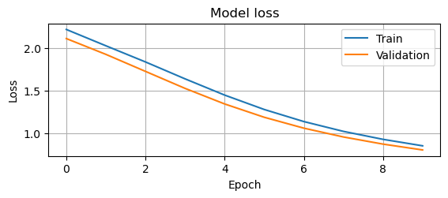

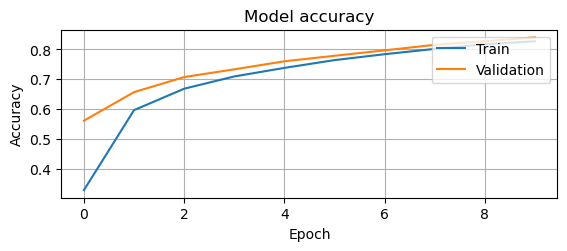

```python
# We now want to plot the train and validation loss functions and accuracy curves
#print(history.history.keys())

# summarize history for loss
# START CODE HERE
plt.figure()

plt.subplot(211)
plt.grid(visible=True)
plt.plot(history.history['loss'])
plt.plot(history.history['val_loss'])
plt.title('Model loss')
plt.ylabel('Loss')
plt.xlabel('Epoch')
plt.legend(['Train', 'Validation'], loc='upper right')
# END CODE HERE
plt.show()

# summarize history for accuracy
# START CODE HERE
plt.subplot(212)
plt.grid(visible=True)
plt.plot(history.history['accuracy'])
plt.plot(history.history['val_accuracy'])
plt.title('Model accuracy')
plt.ylabel('Accuracy')
plt.xlabel('Epoch')
plt.legend(['Train', 'Validation'], loc='upper right')
# END CODE HERE
plt.show()
```

I can conclude that the training was quite good, ultimately achieving a loss of approximately $0.80$ and 84% accuracy, showing that the model was effectively trained as we intended. This is confirmed by the loss function graphs for both training and validation, which decrease monotonically and in tandem, while the accuracy graphs for these same data subsets increase together, almost reaching the same point by the end of the training.

# Computing the confusion matrix

The confusion matrix allows to analyze the trained network performance on a per-class basis

```python
# Example of a confusion matrix using sklearn.metrics
from sklearn.metrics import confusion_matrix

predictions = model.predict(x_test_flat)
# Mind that confusion_matrix requires
matrix = confusion_matrix(y_test_ohe.argmax(axis=1), predictions.argmax(axis=1))
print (matrix)
```

```
313/313 ━━━━━━━━━━━━━━━━━━━━ 1s 3ms/step
[[ 947    0    3    4    1    9   13    1    2    0]
 [   0 1111    9    5    0    0    3    1    6    0]
 [  21   36  825   34   28    2   29   19   37    1]
 [   5   14   35  886    1   19    5   22   17    6]
 [   1   12    5    0  867    0   27    2    2   66]
 [  45   30    9  138   17  530   36   28   41   18]
 [  29   11   17    2   22   12  863    0    2    0]
 [   2   47   27    1   11    3    0  905    4   28]
 [  29   34   26   65   14   17   24   16  712   37]
 [  16   15    9   10  114   11    5   63    5  761]]
```

# Experiments

Note down the performance of the trained network in terms of training and validation accuracy as a reference (save the loss/accuracy graphs of the trained network).

Then, experiment as follow and compare performance with the reference scenario:

- Experiment increasing the batch size (from purely stochastic case) and compare performance with reference.
- Experiment gradually increasing the learning rate starting from 10^-4 and find a reasonable learning rate value the network can tolerate without diverging.
- Experiment replacing the sigmoid activations with Relus and note what happens.

$$\bold{\text{Solution}}$$

We save the perfomance of our ground model in the dict `ground model`:

```python
ground_model = history.history
ground_model["epochs"] = 10
```

## Batch size experiments

Now we will increase the batch size in the following range: $10,50,100,128$

```python
def modelbatch(batch_size = 10):

    model = Sequential()
    model.add(Input(shape=(img_rows*img_cols,)))
    model.add(Dense(300, activation='sigmoid'))
    model.add(Dense(100, activation='sigmoid'))
    model.add(Dense(10, activation='softmax'))

    optimizer=tf.keras.optimizers.SGD(learning_rate= 10e-4)

    model.compile(optimizer=optimizer,
              loss='categorical_crossentropy',
              metrics=['accuracy'])

    history_B10=model.fit(x_train_flat, y_train_ohe,
                    epochs=10,
                    validation_data=(x_test_flat, y_test_ohe),
                    batch_size=batch_size,
                    verbose=1)

    return history_B10.history
```

```python
model_w_b_10 = modelbatch(batch_size = 10)
```

```
6000/6000 ━━━━━━━━━━━━━━━━━━━━ 24s 4ms/step - accuracy: 0.5090 - loss: 2.0413 - val_accuracy: 0.6967 - val_loss: 1.7333
6000/6000 ━━━━━━━━━━━━━━━━━━━━ 24s 4ms/step - accuracy: 0.7252 - loss: 1.4462 - val_accuracy: 0.7793 - val_loss: 1.1705
6000/6000 ━━━━━━━━━━━━━━━━━━━━ 26s 4ms/step - accuracy: 0.7926 - loss: 1.0068 - val_accuracy: 0.8219 - val_loss: 0.8504
6000/6000 ━━━━━━━━━━━━━━━━━━━━ 27s 4ms/step - accuracy: 0.8328 - loss: 0.7704 - val_accuracy: 0.8502 - val_loss: 0.6800
6000/6000 ━━━━━━━━━━━━━━━━━━━━ 26s 4ms/step - accuracy: 0.8550 - loss: 0.6375 - val_accuracy: 0.8674 - val_loss: 0.5776
6000/6000 ━━━━━━━━━━━━━━━━━━━━ 24s 4ms/step - accuracy: 0.8684 - loss: 0.5540 - val_accuracy: 0.8781 - val_loss: 0.5100
6000/6000 ━━━━━━━━━━━━━━━━━━━━ 25s 4ms/step - accuracy: 0.8777 - loss: 0.4972 - val_accuracy: 0.8845 - val_loss: 0.4627
6000/6000 ━━━━━━━━━━━━━━━━━━━━ 27s 4ms/step - accuracy: 0.8839 - loss: 0.4564 - val_accuracy: 0.8905 - val_loss: 0.4280
6000/6000 ━━━━━━━━━━━━━━━━━━━━ 30s 5ms/step - accuracy: 0.8892 - loss: 0.4258 - val_accuracy: 0.8958 - val_loss: 0.4016
6000/6000 ━━━━━━━━━━━━━━━━━━━━ 27s 5ms/step - accuracy: 0.8928 - loss: 0.4022 - val_accuracy: 0.8993 - val_loss: 0.3810
```

```python
model_w_b_50 = modelbatch(batch_size = 50)
```

```
1200/1200 ━━━━━━━━━━━━━━━━━━━━ 7s 5ms/step - accuracy: 0.2522 - loss: 2.2681 - val_accuracy: 0.4491 - val_loss: 2.1882
1200/1200 ━━━━━━━━━━━━━━━━━━━━ 6s 5ms/step - accuracy: 0.5241 - loss: 2.1344 - val_accuracy: 0.5924 - val_loss: 2.0753
1200/1200 ━━━━━━━━━━━━━━━━━━━━ 6s 5ms/step - accuracy: 0.6272 - loss: 2.0201 - val_accuracy: 0.6667 - val_loss: 1.9552
1200/1200 ━━━━━━━━━━━━━━━━━━━━ 7s 6ms/step - accuracy: 0.6730 - loss: 1.8978 - val_accuracy: 0.7046 - val_loss: 1.8273
1200/1200 ━━━━━━━━━━━━━━━━━━━━ 6s 5ms/step - accuracy: 0.7038 - loss: 1.7688 - val_accuracy: 0.7181 - val_loss: 1.6946
1200/1200 ━━━━━━━━━━━━━━━━━━━━ 6s 5ms/step - accuracy: 0.7202 - loss: 1.6378 - val_accuracy: 0.7408 - val_loss: 1.5627
1200/1200 ━━━━━━━━━━━━━━━━━━━━ 6s 5ms/step - accuracy: 0.7397 - loss: 1.5100 - val_accuracy: 0.7549 - val_loss: 1.4371
1200/1200 ━━━━━━━━━━━━━━━━━━━━ 6s 5ms/step - accuracy: 0.7553 - loss: 1.3903 - val_accuracy: 0.7682 - val_loss: 1.3223
1200/1200 ━━━━━━━━━━━━━━━━━━━━ 6s 5ms/step - accuracy: 0.7706 - loss: 1.2817 - val_accuracy: 0.7754 - val_loss: 1.2191
1200/1200 ━━━━━━━━━━━━━━━━━━━━ 7s 6ms/step - accuracy: 0.7813 - loss: 1.1852 - val_accuracy: 0.7958 - val_loss: 1.1283
```

```python
model_w_b_100 = modelbatch(batch_size = 100)
```

```
600/600 ━━━━━━━━━━━━━━━━━━━━ 5s 7ms/step - accuracy: 0.1304 - loss: 2.3341 - val_accuracy: 0.2328 - val_loss: 2.2485
600/600 ━━━━━━━━━━━━━━━━━━━━ 4s 7ms/step - accuracy: 0.3774 - loss: 2.2163 - val_accuracy: 0.4358 - val_loss: 2.1843
600/600 ━━━━━━━━━━━━━━━━━━━━ 6s 9ms/step - accuracy: 0.4812 - loss: 2.1561 - val_accuracy: 0.5212 - val_loss: 2.1234
600/600 ━━━━━━━━━━━━━━━━━━━━ 5s 9ms/step - accuracy: 0.5552 - loss: 2.0957 - val_accuracy: 0.5783 - val_loss: 2.0612
600/600 ━━━━━━━━━━━━━━━━━━━━ 5s 8ms/step - accuracy: 0.5978 - loss: 2.0338 - val_accuracy: 0.6196 - val_loss: 1.9972
600/600 ━━━━━━━━━━━━━━━━━━━━ 5s 7ms/step - accuracy: 0.6285 - loss: 1.9700 - val_accuracy: 0.6494 - val_loss: 1.9313
600/600 ━━━━━━━━━━━━━━━━━━━━ 5s 8ms/step - accuracy: 0.6511 - loss: 1.9044 - val_accuracy: 0.6754 - val_loss: 1.8639
600/600 ━━━━━━━━━━━━━━━━━━━━ 5s 8ms/step - accuracy: 0.6715 - loss: 1.8375 - val_accuracy: 0.6877 - val_loss: 1.7956
600/600 ━━━━━━━━━━━━━━━━━━━━ 5s 8ms/step - accuracy: 0.6873 - loss: 1.7700 - val_accuracy: 0.6950 - val_loss: 1.7271
600/600 ━━━━━━━━━━━━━━━━━━━━ 5s 8ms/step - accuracy: 0.6944 - loss: 1.7026 - val_accuracy: 0.7115 - val_loss: 1.6591
```

```python
model_w_b_128 = modelbatch(batch_size = 128)
```

```
469/469 ━━━━━━━━━━━━━━━━━━━━ 5s 8ms/step - accuracy: 0.1343 - loss: 2.3240 - val_accuracy: 0.1801 - val_loss: 2.2787
469/469 ━━━━━━━━━━━━━━━━━━━━ 4s 8ms/step - accuracy: 0.2528 - loss: 2.2544 - val_accuracy: 0.3213 - val_loss: 2.2338
469/469 ━━━━━━━━━━━━━━━━━━━━ 4s 9ms/step - accuracy: 0.3731 - loss: 2.2131 - val_accuracy: 0.4153 - val_loss: 2.1928
469/469 ━━━━━━━━━━━━━━━━━━━━ 4s 9ms/step - accuracy: 0.4521 - loss: 2.1727 - val_accuracy: 0.4857 - val_loss: 2.1513
469/469 ━━━━━━━━━━━━━━━━━━━━ 4s 9ms/step - accuracy: 0.5106 - loss: 2.1316 - val_accuracy: 0.5443 - val_loss: 2.1091
469/469 ━━━━━━━━━━━━━━━━━━━━ 4s 8ms/step - accuracy: 0.5574 - loss: 2.0896 - val_accuracy: 0.5764 - val_loss: 2.0658
469/469 ━━━━━━━━━━━━━━━━━━━━ 4s 8ms/step - accuracy: 0.5922 - loss: 2.0465 - val_accuracy: 0.5952 - val_loss: 2.0214
469/469 ━━━━━━━━━━━━━━━━━━━━ 4s 9ms/step - accuracy: 0.6052 - loss: 2.0022 - val_accuracy: 0.6220 - val_loss: 1.9756
469/469 ━━━━━━━━━━━━━━━━━━━━ 4s 9ms/step - accuracy: 0.6230 - loss: 1.9565 - val_accuracy: 0.6434 - val_loss: 1.9285
469/469 ━━━━━━━━━━━━━━━━━━━━ 5s 10ms/step - accuracy: 0.6421 - loss: 1.9096 - val_accuracy: 0.6542 - val_loss: 1.8803
```

Now we will compare our results. First we plot our loss and accuary for each of pur models:

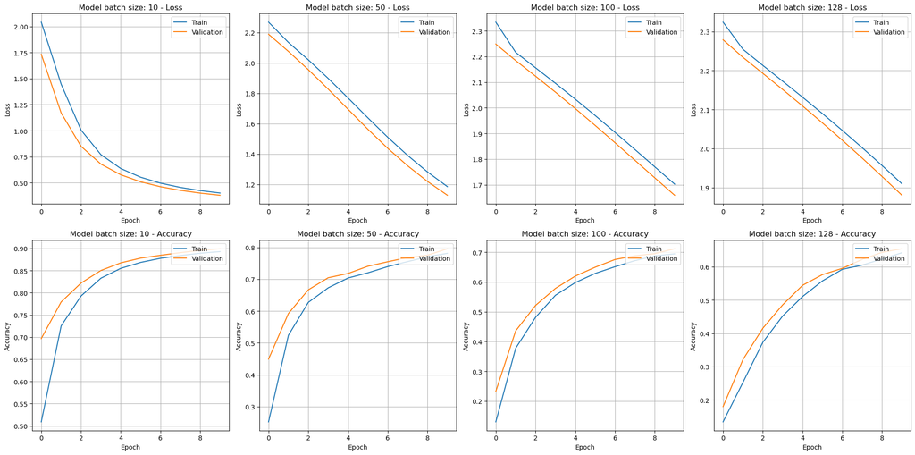

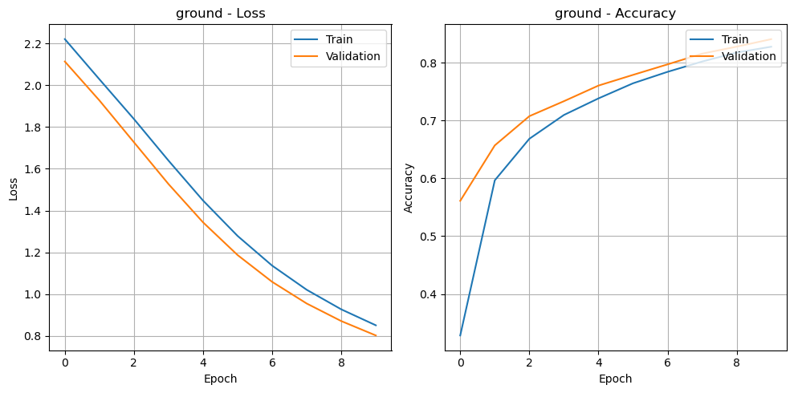

```python
histories = [model_w_b_10, model_w_b_50, model_w_b_100, model_w_b_128, ground_model]
barchsizes = [10, 50, 100, 128]
plt.figure(figsize=(20, 10))

for i in range(4):
    history = histories[i]

    plt.subplot(2, 4, i + 1)
    plt.grid(visible=True)
    plt.plot(history['loss'])
    plt.plot(history['val_loss'])
    plt.title(f'Model batch size: {barchsizes[i]} - Loss')
    plt.ylabel('Loss')
    plt.xlabel('Epoch')
    plt.legend(['Train', 'Validation'], loc='upper right')

    plt.subplot(2, 4, i + 5)
    plt.grid(visible=True)
    plt.plot(history['accuracy'])
    plt.plot(history['val_accuracy'])
    plt.title(f'Model batch size: {barchsizes[i]} - Accuracy')
    plt.ylabel('Accuracy')
    plt.xlabel('Epoch')
    plt.legend(['Train', 'Validation'], loc='upper right')

plt.tight_layout()
plt.show()

plt.figure(figsize=(10, 5))

plt.subplot(1, 2, 1)
plt.grid(visible=True)
plt.plot(histories[4]['loss'])
plt.plot(histories[4]['val_loss'])
plt.title('ground - Loss')
plt.ylabel('Loss')
plt.xlabel('Epoch')
plt.legend(['Train', 'Validation'], loc='upper right')

plt.subplot(1, 2, 2)
plt.grid(visible=True)
plt.plot(histories[4]['accuracy'])
plt.plot(histories[4]['val_accuracy'])
plt.title('ground - Accuracy')
plt.ylabel('Accuracy')
plt.xlabel('Epoch')
plt.legend(['Train', 'Validation'], loc='upper right')

plt.tight_layout()
plt.show()
```

## Learning rate experiments

```python
def modellr(learning_rate_ex = 10e-4):

    model = Sequential()
    model.add(Input(shape=(img_rows*img_cols,)))
    model.add(Dense(300, activation='sigmoid'))
    model.add(Dense(100, activation='sigmoid'))
    model.add(Dense(10, activation='softmax'))

    optimizer=tf.keras.optimizers.SGD(learning_rate= learning_rate_ex)

    model.compile(optimizer=optimizer,
              loss='categorical_crossentropy',
              metrics=['accuracy'])

    history_B10=model.fit(x_train_flat, y_train_ohe,
                    epochs=10,
                    validation_data=(x_test_flat, y_test_ohe),
                    batch_size=10,
                    verbose=1)

    return history_B10.history
```

```python
model_lr_1e_4 = modellr(learning_rate_ex = 10e-4)
```

```
6000/6000 ━━━━━━━━━━━━━━━━━━━━ 29s 5ms/step - accuracy: 0.4967 - loss: 2.0438 - val_accuracy: 0.7055 - val_loss: 1.7358
6000/6000 ━━━━━━━━━━━━━━━━━━━━ 30s 5ms/step - accuracy: 0.7278 - loss: 1.4551 - val_accuracy: 0.7839 - val_loss: 1.1855
6000/6000 ━━━━━━━━━━━━━━━━━━━━ 23s 4ms/step - accuracy: 0.8017 - loss: 1.0276 - val_accuracy: 0.8313 - val_loss: 0.8713
6000/6000 ━━━━━━━━━━━━━━━━━━━━ 25s 4ms/step - accuracy: 0.8365 - loss: 0.7907 - val_accuracy: 0.8526 - val_loss: 0.6971
6000/6000 ━━━━━━━━━━━━━━━━━━━━ 23s 4ms/step - accuracy: 0.8553 - loss: 0.6539 - val_accuracy: 0.8696 - val_loss: 0.5910
6000/6000 ━━━━━━━━━━━━━━━━━━━━ 23s 4ms/step - accuracy: 0.8675 - loss: 0.5673 - val_accuracy: 0.8793 - val_loss: 0.5201
6000/6000 ━━━━━━━━━━━━━━━━━━━━ 25s 4ms/step - accuracy: 0.8767 - loss: 0.5083 - val_accuracy: 0.8863 - val_loss: 0.4709
6000/6000 ━━━━━━━━━━━━━━━━━━━━ 23s 4ms/step - accuracy: 0.8831 - loss: 0.4660 - val_accuracy: 0.8920 - val_loss: 0.4347
6000/6000 ━━━━━━━━━━━━━━━━━━━━ 23s 4ms/step - accuracy: 0.8885 - loss: 0.4344 - val_accuracy: 0.8956 - val_loss: 0.4074
6000/6000 ━━━━━━━━━━━━━━━━━━━━ 27s 4ms/step - accuracy: 0.8926 - loss: 0.4102 - val_accuracy: 0.8995 - val_loss: 0.3867
```

```python
model_lr_1e_3 = modellr(learning_rate_ex = 10e-3)
```

```
6000/6000 ━━━━━━━━━━━━━━━━━━━━ 26s 4ms/step - accuracy: 0.8002 - loss: 0.8350 - val_accuracy: 0.8996 - val_loss: 0.3831
6000/6000 ━━━━━━━━━━━━━━━━━━━━ 24s 4ms/step - accuracy: 0.9051 - loss: 0.3390 - val_accuracy: 0.9195 - val_loss: 0.2884
6000/6000 ━━━━━━━━━━━━━━━━━━━━ 23s 4ms/step - accuracy: 0.9205 - loss: 0.2763 - val_accuracy: 0.9283 - val_loss: 0.2519
6000/6000 ━━━━━━━━━━━━━━━━━━━━ 24s 4ms/step - accuracy: 0.9304 - loss: 0.2402 - val_accuracy: 0.9332 - val_loss: 0.2247
6000/6000 ━━━━━━━━━━━━━━━━━━━━ 24s 4ms/step - accuracy: 0.9383 - loss: 0.2125 - val_accuracy: 0.9412 - val_loss: 0.2010
6000/6000 ━━━━━━━━━━━━━━━━━━━━ 24s 4ms/step - accuracy: 0.9451 - loss: 0.1895 - val_accuracy: 0.9470 - val_loss: 0.1807
6000/6000 ━━━━━━━━━━━━━━━━━━━━ 24s 4ms/step - accuracy: 0.9510 - loss: 0.1700 - val_accuracy: 0.9506 - val_loss: 0.1647
6000/6000 ━━━━━━━━━━━━━━━━━━━━ 24s 4ms/step - accuracy: 0.9562 - loss: 0.1532 - val_accuracy: 0.9550 - val_loss: 0.1508
6000/6000 ━━━━━━━━━━━━━━━━━━━━ 28s 5ms/step - accuracy: 0.9603 - loss: 0.1387 - val_accuracy: 0.9575 - val_loss: 0.1395
6000/6000 ━━━━━━━━━━━━━━━━━━━━ 26s 4ms/step - accuracy: 0.9642 - loss: 0.1262 - val_accuracy: 0.9618 - val_loss: 0.1299
```

```python
model_lr_1e_2 = modellr(learning_rate_ex = 10e-2)
```

```
6000/6000 ━━━━━━━━━━━━━━━━━━━━ 25s 4ms/step - accuracy: 0.9082 - loss: 0.3134 - val_accuracy: 0.9564 - val_loss: 0.1511
6000/6000 ━━━━━━━━━━━━━━━━━━━━ 24s 4ms/step - accuracy: 0.9633 - loss: 0.1234 - val_accuracy: 0.9687 - val_loss: 0.1071
6000/6000 ━━━━━━━━━━━━━━━━━━━━ 26s 4ms/step - accuracy: 0.9765 - loss: 0.0787 - val_accuracy: 0.9740 - val_loss: 0.0846
6000/6000 ━━━━━━━━━━━━━━━━━━━━ 23s 4ms/step - accuracy: 0.9831 - loss: 0.0546 - val_accuracy: 0.9749 - val_loss: 0.0742
6000/6000 ━━━━━━━━━━━━━━━━━━━━ 23s 4ms/step - accuracy: 0.9893 - loss: 0.0380 - val_accuracy: 0.9806 - val_loss: 0.0633
6000/6000 ━━━━━━━━━━━━━━━━━━━━ 23s 4ms/step - accuracy: 0.9922 - loss: 0.0270 - val_accuracy: 0.9794 - val_loss: 0.0630
6000/6000 ━━━━━━━━━━━━━━━━━━━━ 26s 4ms/step - accuracy: 0.9961 - loss: 0.0168 - val_accuracy: 0.9810 - val_loss: 0.0612
6000/6000 ━━━━━━━━━━━━━━━━━━━━ 23s 4ms/step - accuracy: 0.9973 - loss: 0.0121 - val_accuracy: 0.9813 - val_loss: 0.0575
6000/6000 ━━━━━━━━━━━━━━━━━━━━ 24s 4ms/step - accuracy: 0.9988 - loss: 0.0074 - val_accuracy: 0.9816 - val_loss: 0.0604
6000/6000 ━━━━━━━━━━━━━━━━━━━━ 28s 5ms/step - accuracy: 0.9994 - loss: 0.0051 - val_accuracy: 0.9828 - val_loss: 0.0573
```

```python
model_lr_1e_1 = modellr(learning_rate_ex = 10e-1)
```

```
6000/6000 ━━━━━━━━━━━━━━━━━━━━ 28s 5ms/step - accuracy: 0.9223 - loss: 0.2475 - val_accuracy: 0.9492 - val_loss: 0.1539
6000/6000 ━━━━━━━━━━━━━━━━━━━━ 26s 4ms/step - accuracy: 0.9589 - loss: 0.1319 - val_accuracy: 0.9646 - val_loss: 0.1189
6000/6000 ━━━━━━━━━━━━━━━━━━━━ 26s 4ms/step - accuracy: 0.9656 - loss: 0.1092 - val_accuracy: 0.9571 - val_loss: 0.1399
6000/6000 ━━━━━━━━━━━━━━━━━━━━ 26s 4ms/step - accuracy: 0.9695 - loss: 0.0962 - val_accuracy: 0.9626 - val_loss: 0.1213
6000/6000 ━━━━━━━━━━━━━━━━━━━━ 27s 4ms/step - accuracy: 0.9703 - loss: 0.0942 - val_accuracy: 0.9700 - val_loss: 0.1073
6000/6000 ━━━━━━━━━━━━━━━━━━━━ 26s 4ms/step - accuracy: 0.9737 - loss: 0.0825 - val_accuracy: 0.9698 - val_loss: 0.1093
6000/6000 ━━━━━━━━━━━━━━━━━━━━ 26s 4ms/step - accuracy: 0.9765 - loss: 0.0713 - val_accuracy: 0.9707 - val_loss: 0.1003
6000/6000 ━━━━━━━━━━━━━━━━━━━━ 26s 4ms/step - accuracy: 0.9761 - loss: 0.0717 - val_accuracy: 0.9737 - val_loss: 0.0918
6000/6000 ━━━━━━━━━━━━━━━━━━━━ 26s 4ms/step - accuracy: 0.9779 - loss: 0.0663 - val_accuracy: 0.9671 - val_loss: 0.1167
6000/6000 ━━━━━━━━━━━━━━━━━━━━ 27s 4ms/step - accuracy: 0.9802 - loss: 0.0620 - val_accuracy: 0.9635 - val_loss: 0.1280
```

We see the results:

[figure not shown]

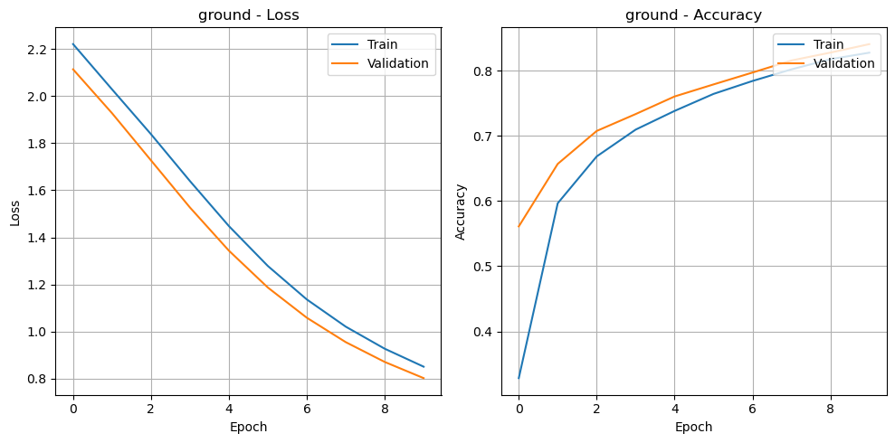

```python
histories = [model_lr_1e_4, model_lr_1e_3, model_lr_1e_2, model_lr_1e_1, ground_model]
lr = [1e-4, 1e-3, 1e-2, 1e-1]
plt.figure(figsize=(20, 10))

for i in range(4):
    history = histories[i]

    plt.subplot(2, 4, i + 1)
    plt.grid(visible=True)
    plt.plot(history['loss'])
    plt.plot(history['val_loss'])
    plt.title(f'Model learning rate: {lr[i]} - Loss')
    plt.ylabel('Loss')
    plt.xlabel('Epoch')
    plt.legend(['Train', 'Validation'], loc='upper right')

    plt.subplot(2, 4, i + 5)
    plt.grid(visible=True)
    plt.plot(history['accuracy'])
    plt.plot(history['val_accuracy'])
    plt.title(f'Model learning rate: {lr[i]} - Accuracy')
    plt.ylabel('Accuracy')
    plt.xlabel('Epoch')
    plt.legend(['Train', 'Validation'], loc='upper right')

plt.tight_layout()
plt.show()

plt.figure(figsize=(10, 5))

plt.subplot(1, 2, 1)
plt.grid(visible=True)
plt.plot(histories[4]['loss'])
plt.plot(histories[4]['val_loss'])
plt.title('ground - Loss')
plt.ylabel('Loss')
plt.xlabel('Epoch')
plt.legend(['Train', 'Validation'], loc='upper right')

plt.subplot(1, 2, 2)
plt.grid(visible=True)
plt.plot(histories[4]['accuracy'])
plt.plot(histories[4]['val_accuracy'])
plt.title('ground - Accuracy')
plt.ylabel('Accuracy')
plt.xlabel('Epoch')
plt.legend(['Train', 'Validation'], loc='upper right')

plt.tight_layout()
plt.show()
```

## ReLu activation

```python
model = Sequential()
model.add(Input(shape=(img_rows*img_cols,)))
model.add(Dense(300, activation='relu'))
model.add(Dense(100, activation='relu'))
model.add(Dense(10, activation='softmax'))

optimizer=tf.keras.optimizers.SGD(learning_rate= 10e-4)

model.compile(optimizer=optimizer,
              loss='categorical_crossentropy',
              metrics=['accuracy'])

history_relu=model.fit(x_train_flat, y_train_ohe,
                    epochs=10,
                    validation_data=(x_test_flat, y_test_ohe),
                    batch_size=10,
                    verbose=1)
```

```
6000/6000 ━━━━━━━━━━━━━━━━━━━━ 28s 4ms/step - accuracy: 0.8477 - loss: 0.5368 - val_accuracy: 0.9186 - val_loss: 0.2870
6000/6000 ━━━━━━━━━━━━━━━━━━━━ 26s 4ms/step - accuracy: 0.9243 - loss: 0.2628 - val_accuracy: 0.9346 - val_loss: 0.2259
6000/6000 ━━━━━━━━━━━━━━━━━━━━ 26s 4ms/step - accuracy: 0.9388 - loss: 0.2121 - val_accuracy: 0.9439 - val_loss: 0.1918
6000/6000 ━━━━━━━━━━━━━━━━━━━━ 27s 4ms/step - accuracy: 0.9479 - loss: 0.1807 - val_accuracy: 0.9503 - val_loss: 0.1707
6000/6000 ━━━━━━━━━━━━━━━━━━━━ 26s 4ms/step - accuracy: 0.9552 - loss: 0.1583 - val_accuracy: 0.9520 - val_loss: 0.1592
6000/6000 ━━━━━━━━━━━━━━━━━━━━ 27s 4ms/step - accuracy: 0.9598 - loss: 0.1411 - val_accuracy: 0.9568 - val_loss: 0.1429
6000/6000 ━━━━━━━━━━━━━━━━━━━━ 26s 4ms/step - accuracy: 0.9642 - loss: 0.1273 - val_accuracy: 0.9602 - val_loss: 0.1335
6000/6000 ━━━━━━━━━━━━━━━━━━━━ 26s 4ms/step - accuracy: 0.9673 - loss: 0.1159 - val_accuracy: 0.9625 - val_loss: 0.1260
6000/6000 ━━━━━━━━━━━━━━━━━━━━ 26s 4ms/step - accuracy: 0.9701 - loss: 0.1063 - val_accuracy: 0.9654 - val_loss: 0.1171
6000/6000 ━━━━━━━━━━━━━━━━━━━━ 27s 4ms/step - accuracy: 0.9724 - loss: 0.0978 - val_accuracy: 0.9666 - val_loss: 0.1130
```

Let's see the comparation:

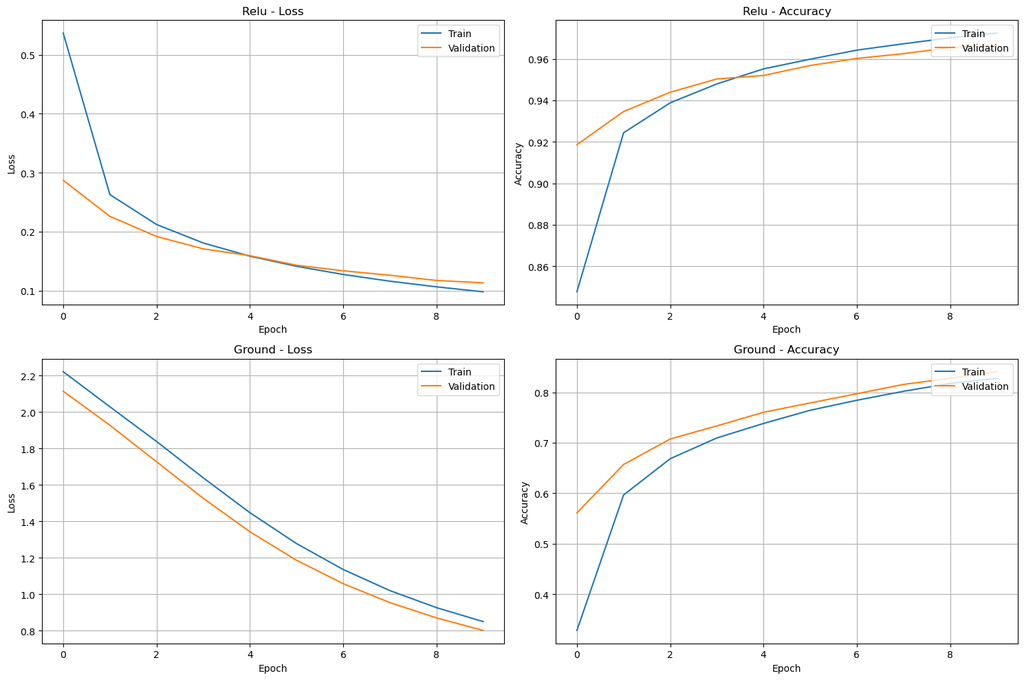

```python
plt.figure(figsize=(15, 10))

histories = [history_relu.history, ground_model]

model_configs = [
    {'name': 'Relu', 'history': histories[0]},
    {'name': 'Ground', 'history': histories[1]}
]

for i, config in enumerate(model_configs):
    plt.subplot(2, 2, i * 2 + 1)
    plt.grid(visible=True)
    plt.plot(config['history']['loss'])
    plt.plot(config['history']['val_loss'])
    plt.title(f'{config["name"]} - Loss')
    plt.ylabel('Loss')
    plt.xlabel('Epoch')
    plt.legend(['Train', 'Validation'], loc='upper right')

    # Accuracy
    plt.subplot(2, 2, i * 2 + 2)
    plt.grid(visible=True)
    plt.plot(config['history']['accuracy'])
    plt.plot(config['history']['val_accuracy'])
    plt.title(f'{config["name"]} - Accuracy')
    plt.ylabel('Accuracy')
    plt.xlabel('Epoch')
    plt.legend(['Train', 'Validation'], loc='upper right')

plt.tight_layout()
plt.show()
```

We see that in the case where the activation functions are ReLU, the model achieves a loss of (approximately) $0.1$, while the base model reaches a loss of $0.8$. This indicates that the model with ReLU could be better than the base model, which is confirmed by looking at the accuracy graphs: In the model with ReLU we obtain a value of $0.96$, while in the base model we only get $0.8$.